## Différence entre les SVM et les réseaux de neurones : classification multi-classes

**Théorie :**

- Pour les SVM
- Pour les réseaux de neurones

**Exercices :**

- Exercice 1 : matrice de confusion
- Exercice 2 : confidence via softmax

### Pour les SVM

Les SVM sont de manière inhérente des classfieurs binaires. La méthode traditionnelle pour résoudre un problème multi-classes est d'utiliser la politique du "one versus the rest", c'est-à-dire d'attribuer un SVM par classe. Pour entraîner le classifieur pour la classe $y$, tous les exemples du jeu de données appartenant à la classe $k$ sont considérés comme des exemples positifs et tous les autres exemples comme négatifs. Un classifieur $C$ doit donc trouver l'hyperplan qui différencie les exemples de sa classe et les exemples des autres classes. Lors de l'inférence (c'est-à-dire lorsqu'on test le système une fois entrainé), on attribue la classe $k$ à l'entrée $x$ du classifieur $C$ qui aura présenté la plus vaste marge pour ce même exemple $x$.

Nous pouvons tester un problème multi-classes avec SVM avec le jeu de données LFW (Labeled Faces in the Wild).

```
Downloading LFW metadata: https://ndownloader.figshare.com/files/5976012
Downloading LFW metadata: https://ndownloader.figshare.com/files/5976009
Downloading LFW metadata: https://ndownloader.figshare.com/files/5976006
Downloading LFW data (~200MB): https://ndownloader.figshare.com/files/5976015
```

```
Nombre de classes: (8,)
['Ariel Sharon' 'Colin Powell' 'Donald Rumsfeld' 'George W Bush'
 'Gerhard Schroeder' 'Hugo Chavez' 'Junichiro Koizumi' 'Tony Blair']
Dataset shape (1348, 62, 47)
```

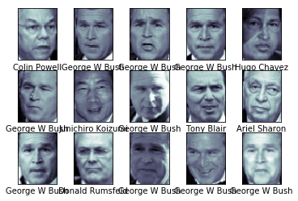

```python
import matplotlib.pyplot as plt
from sklearn.multiclass import OneVsRestClassifier
from sklearn.datasets import fetch_lfw_people

faces = fetch_lfw_people(min_faces_per_person=60)
print("Nombre de classes:", faces.target_names.shape)
print(faces.target_names)
print("Dataset shape",faces.images.shape)

fig, ax = plt.subplots(3, 5)
for i, axi in enumerate(ax.flat):
    axi.imshow(faces.images[i], cmap='bone')
    axi.set(xticks=[], yticks=[],
            xlabel=faces.target_names[faces.target[i]])

plt.show()
```

Pour cet exercice, nous allons faire une expérience en bonne et due forme. Dans la section précédente, nous testions le système directement sur les données utilisées pour l'entraînement : ce n'est pas correct. Pour tester l'efficacité de l'apprentissage d'une machine, lors de l'inférence, il faut donné des exemples qui **n'ont jamais été vus par le système**. On "split" donc le jeu de données en deux parties : train et test.

```python
from sklearn.model_selection import train_test_split
Xtrain, Xtest, ytrain, ytest = train_test_split(faces.data, faces.target,
                                                random_state=1)
print(Xtrain.shape)
print(Xtest.shape)
```

```
(1011, 2914)
(337, 2914)
```

Nous devons aussi soulever une deuxième question : que mettre en entrée de la machine ? Nous voyons dans la sortie précédente qu'un exemple (ou une image) a pour dimension $62 \times 47$ soit un vecteur $x \in \mathbb{R}^{2914}$. Peut-on se permettre de donner la matrice des pixels aplatit (flatten) en un vecteur en entrée ?

Le SVM a besoin en entrée de caractéristiques principales, ou discriminantes qu'il peut moduler pour tracer son hyperplan entre les classes. Une caractéristique, aussi appelée **feature**, est un élément composant le vecteur $x$. Ainsi, notre vecteur $x$ dispose de 2914 features, ici des pixels. Existe-il une corrélation telle entre les features que la SVM soit capable de les utiliser pour discriminer les classes ? Essayons :

```
34.64870834350586
```

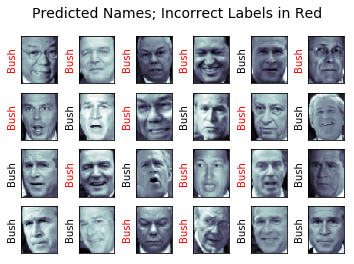

```python
from sklearn.svm import SVC
from sklearn.decomposition import PCA
from sklearn.pipeline import make_pipeline
import time

model = OneVsRestClassifier(SVC(kernel='rbf', gamma="auto"))

start = time.time()
model.fit(Xtrain, ytrain)
end = time.time()
print(end - start)

yfit = model.predict(Xtest)

fig, ax = plt.subplots(4, 6)
for i, axi in enumerate(ax.flat):
    axi.imshow(Xtest[i].reshape(62, 47), cmap='bone')
    axi.set(xticks=[], yticks=[])
    axi.set_ylabel(faces.target_names[yfit[i]].split()[-1],
                   color='black' if yfit[i] == ytest[i] else 'red')
fig.suptitle('Predicted Names; Incorrect Labels in Red', size=14)

plt.show()
```

Non seulement le temps d'exécution est très long, mais les résultats sont mauvais.

Pour palier à ce problème haute dimension ([curse of dimensionality](https://en.wikipedia.org/wiki/Curse_of_dimensionality)), une technique appelée PCA ([Analyse de composante principales](https://stats.stackexchange.com/a/140579)) est une méthode statistique (dont les principes ont été formulés en 1901 !) qui a trouvé son application en reconnaissance de visage et compression d'image. La PCA permet de trouver des patterns dans des données hautes dimensions et de les exprimer dans une dimensionnalité réduite de manière que les similarités et différences (entendre variance et corrélation linéaire) entre les features soient mises en avant.

Nous choisissons une PCA qui retient 150 features par image :

```
1.281346082687378
```

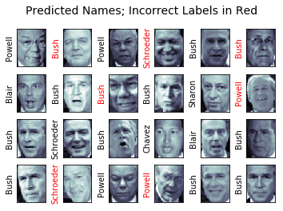

```python
from sklearn.svm import SVC
from sklearn.decomposition import PCA
from sklearn.pipeline import make_pipeline
import time


pca = PCA(n_components=150, whiten=True, random_state=1) #random is seed
svc = OneVsRestClassifier(SVC(kernel='rbf', gamma="auto"))
model = make_pipeline(pca, svc)

from sklearn.model_selection import train_test_split
Xtrain, Xtest, ytrain, ytest = train_test_split(faces.data, faces.target,
                                                random_state=1)

start = time.time()
model.fit(Xtrain, ytrain)
end = time.time()
print(end - start)
yfit = model.predict(Xtest)

fig, ax = plt.subplots(4, 6)
for i, axi in enumerate(ax.flat):
    axi.imshow(Xtest[i].reshape(62, 47), cmap='bone')
    axi.set(xticks=[], yticks=[])
    axi.set_ylabel(faces.target_names[yfit[i]].split()[-1],
                   color='black' if yfit[i] == ytest[i] else 'red')
fig.suptitle('Predicted Names; Incorrect Labels in Red', size=14)

plt.show()
```

La PCA permet de réduire l'erreur à 7/24 sur ces 24 exemples du test-set.

**Exercice :** en utilisant sk-learn, trouvez l'accuracy pour les 8 classes et imprimer la matrice de confusion

Nous pouvons vérifier le contenu du modèle OneVsRestClassifier, nous avons bien 8 SVM empilés :

```python
print(len(model.named_steps['onevsrestclassifier'].estimators_))
print(model.named_steps['onevsrestclassifier'].estimators_)
```

```
8
[SVC(C=1.0, cache_size=200, class_weight=None, coef0=0.0,
    decision_function_shape='ovr', degree=3, gamma='auto', kernel='rbf',
    max_iter=-1, probability=False, random_state=None, shrinking=True,
    tol=0.001, verbose=False), SVC(C=1.0, cache_size=200, class_weight=None, coef0=0.0,
    decision_function_shape='ovr', degree=3, gamma='auto', kernel='rbf',
    max_iter=-1, probability=False, random_state=None, shrinking=True,
    tol=0.001, verbose=False), SVC(C=1.0, cache_size=200, class_weight=None, coef0=0.0,
    decision_function_shape='ovr', degree=3, gamma='auto', kernel='rbf',
    max_iter=-1, probability=False, random_state=None, shrinking=True,
    tol=0.001, verbose=False), SVC(C=1.0, cache_size=200, class_weight=None, coef0=0.0,
    decision_function_shape='ovr', degree=3, gamma='auto', kernel='rbf',
    max_iter=-1, probability=False, random_state=None, shrinking=True,
    tol=0.001, verbose=False), SVC(C=1.0, cache_size=200, class_weight=None, coef0=0.0,
    decision_function_shape='ovr', degree=3, gamma='auto', kernel='rbf',
    max_iter=-1, probability=False, random_state=None, shrinking=True,
    tol=0.001, verbose=False), SVC(C=1.0, cache_size=200, class_weight=None, coef0=0.0,
    decision_function_shape='ovr', degree=3, gamma='auto', kernel='rbf',
    max_iter=-1, probability=False, random_state=None, shrinking=True,
    tol=0.001, verbose=False), SVC(C=1.0, cache_size=200, class_weight=None, coef0=0.0,
    decision_function_shape='ovr', degree=3, gamma='auto', kernel='rbf',
    max_iter=-1, probability=False, random_state=None, shrinking=True,
    tol=0.001, verbose=False), SVC(C=1.0, cache_size=200, class_weight=None, coef0=0.0,
    decision_function_shape='ovr', degree=3, gamma='auto', kernel='rbf',
    max_iter=-1, probability=False, random_state=None, shrinking=True,
    tol=0.001, verbose=False)]
```

### Pour les réseaux de neurones

Nous allons maintenant attaquer le même exercice avec des réseaux de neurones. Grâce à sa topologie, une suite de transformations linéaires (via les perceptrons) et de fonctions non-linéaires (sigmoide, tanh, relu,...), une couche cachée $h_t$ n'est pas contrainte de moduler les entrées "raw" (comme des pixels) mais bien la sortie de la couche $h_{t-1}$ (sauf la couche $h_0$ qui prend les pixels). Un réseau de neurones apprend donc ses propres features dans ses couches cachées nécessaires à la classification finale. Un NN avec deux couches cachées se représente comme tel :

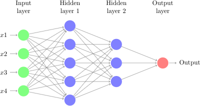

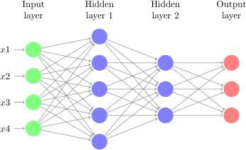

Cet avantage est non négligable : les jeux de données utilisés pour créer les systèmes de reconnaissance visuelle à la pointe comprennent jusqu'à 1000 classes (voir [ImageNet](http://image-net.org/index)).

**Similarités :**

- Le perceptron est similaire à un SVM à noyau linéaire
- Un SVM à noyau est équivalent à un NN deux couches
- Certains noyaux ont la même propriété que d'ajouter des neurones (ou perceptron) dans les couches cachées

**Différences :**

- Algorithme de mise à jour du modèle
- Les NN sont heuristiques, les SVM fondés théoriquement
- La topologie du NN lui permet de calculer lui même ses features discriminantes dans ses couches cachées, un SVM doit requérir à des algorithmes comme la PCA
- La topologie du NN lui permet de traiter des problèmes multi-classes en un bloc, le SVM doit empiler plusieurs instances spécifiques à chaque classe.

```python
import numpy as np
import matplotlib.pyplot as plt
import torch.nn.functional as F
import torch.nn as nn
import torch
```

```python
from sklearn.datasets import fetch_lfw_people
from sklearn.model_selection import train_test_split
```

```python
faces = fetch_lfw_people(min_faces_per_person=60)
print("Nombre de classes:", faces.target_names.shape)
print(faces.target_names)
print("Dataset shape",faces.images.shape)
```

```
Nombre de classes: (8,)
['Ariel Sharon' 'Colin Powell' 'Donald Rumsfeld' 'George W Bush'
 'Gerhard Schroeder' 'Hugo Chavez' 'Junichiro Koizumi' 'Tony Blair']
Dataset shape (1348, 62, 47)
```

```python
#Les images doivent être en 3D. Ici les images sont en noir et blanc, donc la première dim
# est 1. Dans le cas du RGB, la dimension est de 3
images_reshape = np.expand_dims(faces.images, axis=1) #1348 x 1 x 62 x 47
Xtrain, Xtest, ytrain, ytest = train_test_split(images_reshape, faces.target,
                                                random_state=1)

# transformation des inputs numpy vers torch
X = torch.from_numpy(Xtrain).cuda().float()
y = torch.from_numpy(ytrain).cuda().long()

# network dimensions
n_input_dim = X.shape[1]
n_output = faces.target_names.shape[0]  # output = nombre de classes dans le dataset (8)
```

Pour construire le modèle, nous utilisons ici des convolutions (conv2d). C'est un cas particulier des couches linéaires pleinement connectées comme vu précédemment où certaines connections sont coupées :

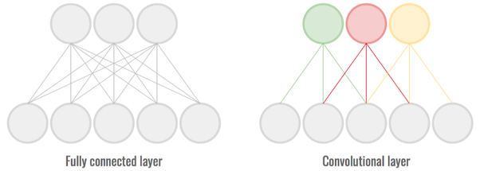

Nous verrons plus en détails les propriétés des convolutions dans les prochaines sections.

```python
# Build the network
class Net(nn.Module):
    def __init__(self):
        super(Net, self).__init__()
        self.conv1 = nn.Conv2d(1, 6, 5)
        self.pool = nn.MaxPool2d(2, 2)
        self.conv2 = nn.Conv2d(6, 16, 5)
        self.conv3 = nn.Conv2d(16, 32, 5)
        self.fc1 = nn.Linear(32 * 4 * 2, 120)
        self.fc2 = nn.Linear(120, n_output)
        self.dropout = nn.Dropout(p=0.2)

    def forward(self, x):
        x = self.pool(F.relu(self.conv1(x)))
        x = self.pool(F.relu(self.conv2(x)))
        x = self.pool(F.relu(self.conv3(x)))
        x = x.view(-1, 32 * 4 * 2)
        x = self.dropout(x)
        x = F.relu(self.fc1(x))
        x = self.dropout(x)
        x = F.relu(self.fc2(x))
        return x
```

[output not shown]

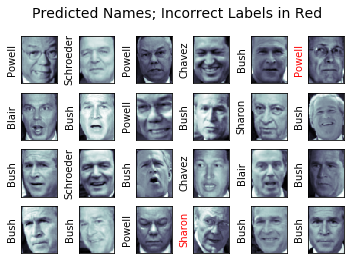

```python
net = Net().cuda()

loss_func = nn.CrossEntropyLoss() #fonction de la loss
learning_rate = 0.002 #pas d'apprentissage
optimizer = torch.optim.SGD(net.parameters(), lr=learning_rate, momentum=0.9) # descente de gradient
num_iterations = 5000
batch_size = 128

for i in range(num_iterations):
    rand = np.random.choice(X.shape[0], batch_size)
    input = X[rand]
    target = y[rand]

    optimizer.zero_grad()

    # forward pass
    prob = net(input)

    #calcul de la loss
    loss = loss_func(prob, target)

    #mise à jour du réseau
    loss.backward()
    optimizer.step()

    #print de la loss
    if i%200==0:
        print("Iter {} - loss: {:.2f}".format(i,loss.item()))


net.eval()
x = torch.from_numpy(Xtest).cuda()
probs = net(x)

#le réseau sort de probabilités pour chaque classe (chaque réponse possible)
#on prend la confidence "max"du réseau comme réponse
answers = torch.argmax(probs, dim=1)
answers = answers.detach().cpu().numpy()

fig, ax = plt.subplots(4, 6)
for i, axi in enumerate(ax.flat):
    axi.imshow(Xtest[i].reshape(62, 47), cmap='bone')
    axi.set(xticks=[], yticks=[])
    axi.set_ylabel(faces.target_names[answers[i]].split()[-1],
                   color='black' if answers[i] == ytest[i] else 'red')
fig.suptitle('Predicted Names; Incorrect Labels in Red', size=14)
plt.show()
```

**Attention :** Nous noterons que nous utilisons plus la **BCELoss** (binary cross entropy loss, pour deux classes) qui est un cas particulier de la categorical cross entropy (ici **CrossEntropyLoss**) généralisant pour un nombre infini de classes. Nous remarquons aussi la disparition de la sigmoide. La sigmoide a été remplacée directement dans la fonction CrossEntropyLoss [[SOURCE]](https://pytorch.org/docs/stable/_modules/torch/nn/functional.html#cross_entropy) par la fonction **[SoftMax](https://medium.com/data-science-bootcamp/understand-the-softmax-function-in-minutes-f3a59641e86d)** qui est une généralisation de la sigmoide. Soit un vecteur de probabilité $p$, la fonction sigmoide écrase la probabilité $p_i$ indépendamment des autres probabilités dans le vecteur. La fonction softmax mettra cette probabilité en relation de grandeur avec les autres, de manière que la somme des probabilités régularisées vaut 1.

```python
import torch

x = torch.tensor([0.5, 1.8, 0.1])
print(torch.sigmoid(x))
print(torch.sigmoid(x).sum(0))
print(torch.nn.functional.softmax(x, dim=0))
print(torch.nn.functional.softmax(x, dim=0).sum(0))
```

```
tensor([0.6225, 0.8581, 0.5250])
tensor(2.0056)
tensor([0.1873, 0.6872, 0.1255])
tensor(1.0000)
```

Ce choix de régularisation peut sembler arbitraire, mais la fonction **softmax est simplement une généralisation de la fonction sigmoidale** pour des problèmes multi-classes (à plusieurs sorties). Utiliser la fonction softmax pour un problème binaire est équivalent à utiliser une sigmoide. Nous voyons qu'il est d'ailleurs facile de passer de l'un à l'autre : $$\text{sigmoid}(x)=\frac{1}{1 + e^{- x}}$$ $$\text{softmax}(\mathbf{x})_i = \frac{e^{x_i}}{\sum_{j=1}^K e^{x_j}} \text{ for } i = 1, \dotsc , K \text{ and } \mathbf x=(x_1,\dotsc,x_K) \in\mathbb{R}^K$$ Dans le softmax, chaque probabilité $x_i$ est divisée (et donc mise en relation) par la somme de tout les probabilités $x_1, ..., x_K$.

**Exercice :** pour un exemple du test-set, sortez les probabilités et normalisez-les avec la fonction torch.nn.softmax et donnez la confiance (probabilité) avec laquelle le modèle donne sa réponse